# Reproducion_Culliney_2012

Ingrid Molina Mora

12/11/2020

## **"Seed dispersal by a captive corvid: the role of the Alala (** *Corvus hawaiiensis* **) in shaping Hawaii’s plant communities"**

### (spoiler) *¡Una Reproducción de Artículo Éxitosa!*

##### **1.** ¿Qué es lo que investiga el artículo

Este artículo de 2012 documentó el papel potencial del cuervo hawaiano Alala en el mantenimiento y restauración de los bosques de Hawái a través de la dispersión de semillas.

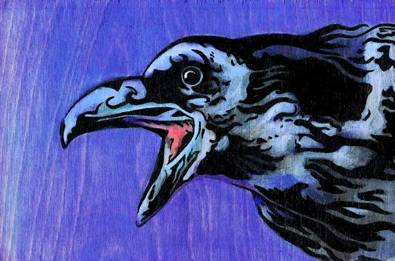

Impresión sobre madera, J. Medina

El *objetivo* era documentar el papel potencial del Alala en la restauración de los bosques Hawaianos.

Usaron ensayos de alimentación con Alalas cautivos para determinar **(1)** el potencial de dispersión del Alala en cautiverio para las especies de plantas fructíferas nativas de Hawaii; **(2)** si la edad y el sexo de las aves influyen en las opciones de alimentación y dispersión de semillas; y **(3)** si la ingestión de Alala da como resultado una mejor germinación de las semillas, ya que el proceso digestivo del ave podría preparar químicamente semillas para su germinación.

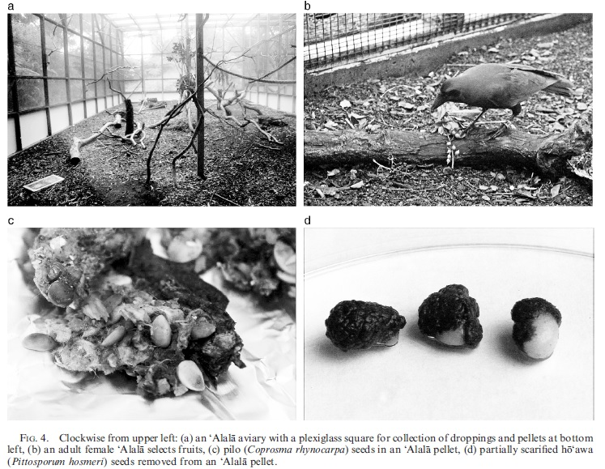

##### **2** ¿Qué parte del análisis se reprodujo y porqué?

Reproduje las 3 partes del análisis porque en este caso el artículo brindaba un link al [Repositorio en Figshare](https://figshare.com/collections/Seed_dispersal_by_a_captive_corvid_the_role_of_the_Alal_i_Corvus_hawaiiensis_i_in_shaping_Hawai_i_s_plant_communities/3295529) donde estaba el set de datos y tres documentos de word donde el código estaba bien explicado (Había en principio un enlace a scrips de R pero estaban vacíos)

**Los métodos**

Veremos entonces:

- Sexo: Macho, Hembra
- Edad: Juvenil, Adulto
- Observaciones: Carry, Eating
- 4 tratamientos para Germinación: A mano, Cuitas, Pellets, Fruto entero
- Especies de plantas: 14 (*Acá presentaré el código y resultados para 1 especie*)

##### **3** Código y resultados

-Cargo las librerías MuMIn y Betareg (Antes asegurarnos de que los paquetes están instalados)

```r
library(MuMIn)

library(betareg)
```

Yo tuve que instalar el paquete Betareg en una versión del paquete mucho más nueva que la utilizada por las investigadoras en 2012 (Obtenía un Warning al respecto pero esto podría evitarse utilizado el sistema **packrat**), además Mi versión de R es 3.6.1. mientras que la de ellas era la R version 2.13.0.  
Decidí continuar:

#### *Comportamiento de forrajeo y dispersión de semillas*

(*Se debe cambiar de nombre porque es distinto en el word que proveen que en los archivos txt*)

```r
Alala.carry <- as.data.frame(read.delim(file="Data.Alala.carry.txt", header=TRUE, sep="\t"))
```

```r
names(Alala.carry)
```

```
## [1] "Name"    "Sex"     "Plant"   "carried" "given"   "carries" "Age"
```

```r
unique(Alala.carry$Plant)
```

```
##  [1] CHETR  CLEHA  COPRH  ILEAN  MYOSA  MYRLA  PIPAL  PITHO  PLEHA  PRISCb
## [11] PRISCg STYTA  TETHA  VACRE
## 14 Levels: CHETR CLEHA COPRH ILEAN MYOSA MYRLA PIPAL PITHO PLEHA ... VACRE
```

```r
# primera parte alala carry behavior, leer datos y crear un subset para la primera especie de planta Olapa (Cheirodendron trigynum)"CHETR"
Alala.carry <- as.data.frame(read.delim(file="Data.Alala.carry.txt", header=TRUE, sep="\t"))
names(Alala.carry)
```

```
## [1] "Name"    "Sex"     "Plant"   "carried" "given"   "carries" "Age"
```

```r
unique(Alala.carry$Plant)
```

```
##  [1] CHETR  CLEHA  COPRH  ILEAN  MYOSA  MYRLA  PIPAL  PITHO  PLEHA  PRISCb
## [11] PRISCg STYTA  TETHA  VACRE
## 14 Levels: CHETR CLEHA COPRH ILEAN MYOSA MYRLA PIPAL PITHO PLEHA ... VACRE
```

```r
CHETR <- subset(Alala.carry, Plant== "CHETR")
```

```r
#Regresión;
CHETR.glm <- glm(CHETR$carries~ CHETR$Sex + CHETR$Age,weights=CHETR$given, na.action = na.fail)
#Resumen de estadísticas
summary(CHETR.glm)
```

```
##
## Call:
## glm(formula = CHETR$carries ~ CHETR$Sex + CHETR$Age, weights = CHETR$given,
##     na.action = na.fail)
##
## Deviance Residuals:
##      Min        1Q    Median        3Q       Max
## -0.33872  -0.24657  -0.08755  -0.02584   2.24534
##
## Coefficients:
##             Estimate Std. Error t value Pr(>|t|)
## (Intercept)  0.08468    0.02881   2.939  0.00483 **
## CHETR$Sex   -0.05699    0.02907  -1.961  0.05507 .
## CHETR$Age   -0.02102    0.02986  -0.704  0.48453
## ---
## Signif. codes:  0 '***' 0.001 '**' 0.01 '*' 0.05 '.' 0.1 ' ' 1
##
## (Dispersion parameter for gaussian family taken to be 0.1787553)
##
##     Null deviance: 10.3767  on 56  degrees of freedom
## Residual deviance:  9.6528  on 54  degrees of freedom
## AIC: -85.926
##
## Number of Fisher Scoring iterations: 2
```

Tablas del AIC y sus coeficientes. Acá obtenía un error porque la función dredge no aceptaba el argumento “na.action”. tuve que devolverme al glm y *agregar glm(…, na.action = na.fail).*

```r
CHETR.AIC <- dredge(CHETR.glm)
```

```
## Fixed term is "(Intercept)"
```

```r
#Valores del AIC
CHETR.AIC
```

```
## Global model call: glm(formula = CHETR$carries ~ CHETR$Sex + CHETR$Age, weights = CHETR$given,
##     na.action = na.fail)
## ---
## Model selection table
##     (Int)  CHE$Age  CHE$Sex df logLik  AICc delta weight
## 3 0.07042          -0.05433  3 46.702 -87.0  0.00  0.478
## 1 0.04297                    2 44.902 -85.6  1.37  0.241
## 4 0.08468 -0.02102 -0.05699  4 46.963 -85.2  1.80  0.195
## 2 0.05120 -0.01340           3 45.003 -83.6  3.40  0.087
## Models ranked by AICc(x)
```

`write.table(CHETR.AIC,"CARRY.CHETR.AIC.txt",sep="S", col.names=TRUE)`

Resultados iguales a los del artículo:

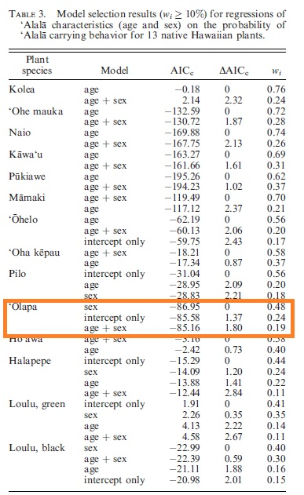

Promediar el modelo y obtener los estimados promediados del modelo para cada uno de los coeficientes. *Hubo un error por el código original ya que la función model.avg ha tenido cambios y no requiere especificar el “method”* así que lo eliminé.

```r
#estimados promediados del modelo
average.CHETR <- model.avg(get.models(CHETR.AIC, seq(nrow(CHETR.AIC))))
CHETR.Age <- CHETR$Age
CHETR.Sex <- CHETR$Sex
```

```r
# modelos promediadios con los errores estandar
newdata.CHETR <- as.data.frame(cbind(CHETR.Age,CHETR.Sex))
pred.avg.CHETR <- predict(average.CHETR, newdata.CHETR,se.fit=TRUE, type="response")
results.CHETR <- unique(cbind(newdata.CHETR,pred.avg.CHETR$fit,pred.avg.CHETR$se.fit))
results.CHETR
```

```
##    CHETR.Age CHETR.Sex pred.avg.CHETR$fit pred.avg.CHETR$se.fit
## 1          0         1         0.02788043            0.02443427
## 3          0         0         0.06491395            0.02615239
## 19         1         0         0.05965624            0.02340999
## 20         1         1         0.02262272            0.02411829
```

Por último se produce un archivo de texto de los resultados de las estimaciones promediadas para poder leerlas en excel `write.table(results.CHETR,"CARRY.results.CHETR.txt",sep="S", col.names=TRUE)` **OJO** El delimitador es “S”, se ve así:

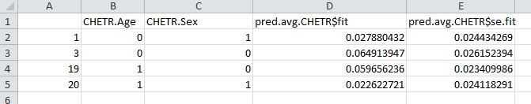

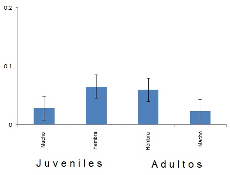

y es igual a los resultados del artículo

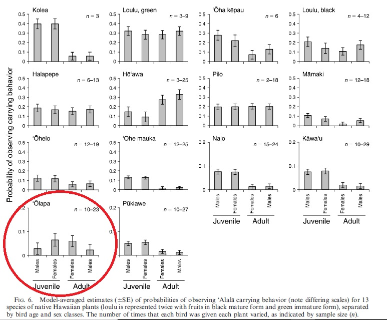

#### *Comportamiento de alimentación*

(*Acá igualmente se debe cambiar de nombre porque es distinto en el word que proveen que en los archivos txt*)

```r
Alala.eat <- as.data.frame(read.delim(file="Data.Alala.eat.txt", header=TRUE, sep="\t"));
names(Alala.eat)
```

```
## [1] "Name"  "Sex"   "Plant" "eaten" "given" "eats"  "Age"
```

```r
unique(Alala.eat$Plant)
```

```
##  [1] CHETR  CLEHA  COPRH  ILEAN  MYOSA  MYRLA  PIPAL  PITHO  PLEHA  PRISCb
## [11] PRISCg STYTA  TETHA  VACRE
## 14 Levels: CHETR CLEHA COPRH ILEAN MYOSA MYRLA PIPAL PITHO PLEHA ... VACRE
```

```r
#Se hace un supset como en el caso anterior para olapa
CHETR <- subset(Alala.eat, Plant== "CHETR")

#regresión
CHETR.glm <- glm(CHETR$eats~ CHETR$Sex + CHETR$Age,weights=CHETR$given, na.action = na.fail)
#resumen de estadísticas:
summary(CHETR.glm)
```

```
##
## Call:
## glm(formula = CHETR$eats ~ CHETR$Sex + CHETR$Age, weights = CHETR$given,
##     na.action = na.fail)
##
## Deviance Residuals:
##      Min        1Q    Median        3Q       Max
## -0.79609  -0.34629  -0.27488  -0.08327   3.14236
##
## Coefficients:
##             Estimate Std. Error t value Pr(>|t|)
## (Intercept)  0.20555    0.05319   3.865 0.000301 ***
## CHETR$Sex   -0.06791    0.05367  -1.265 0.211161
## CHETR$Age   -0.11614    0.05513  -2.107 0.039798 *
## ---
## Signif. codes:  0 '***' 0.001 '**' 0.01 '*' 0.05 '.' 0.1 ' ' 1
##
## (Dispersion parameter for gaussian family taken to be 0.6093781)
##
##     Null deviance: 36.220  on 56  degrees of freedom
## Residual deviance: 32.906  on 54  degrees of freedom
## AIC: -16.02
##
## Number of Fisher Scoring iterations: 2
```

Tablas del AIC y sus coeficientes.

```r
CHETR.AIC <- dredge(CHETR.glm)
```

```
## Fixed term is "(Intercept)"
```

```r
CHETR.AIC
```

```
## Global model call: glm(formula = CHETR$eats ~ CHETR$Sex + CHETR$Age, weights = CHETR$given,
##     na.action = na.fail)
## ---
## Model selection table
##     (Int) CHE$Age  CHE$Sex df logLik  AICc delta weight
## 2 0.16570 -0.1071           3 11.177 -15.9  0.00  0.413
## 4 0.20550 -0.1161 -0.06791  4 12.010 -15.3  0.65  0.298
## 1 0.09988                   2  9.275 -14.3  1.57  0.188
## 3 0.12680         -0.05320  3  9.758 -13.1  2.84  0.100
## Models ranked by AICc(x)
```

Promediado del modelo y estimados promediados para cada uno de los coeficientes. Los estimados me dan información sobre las magnitudes de los efectos de edad y sexo

```r
average.CHETR <- model.avg(get.models(CHETR.AIC, seq(nrow(CHETR.AIC))))
CHETR.Age <- CHETR$Age
CHETR.Sex <- CHETR$Sex
#Estimados del modelo promediados y Errores Estandar (EE)
newdata.CHETR <- as.data.frame(cbind(CHETR.Age,CHETR.Sex))
pred.avg.CHETR <- predict(average.CHETR, newdata.CHETR,se.fit=TRUE, type="response")
results.CHETR <- unique(cbind(newdata.CHETR,pred.avg.CHETR$fit,pred.avg.CHETR$se.fit))
# Al final tambien se crea un archivo de exel y así con cada una de las especies de plantas para cada una de las tres partes
```

El gráfico hecho en excel con los resultados obtenido fue igual al del artículo.

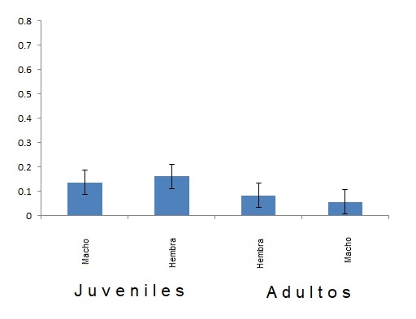

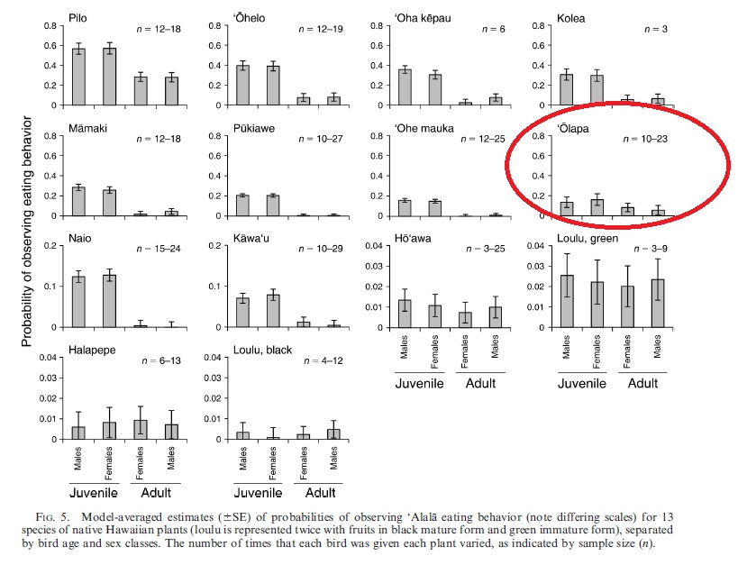

No encontré más errores ni obstaculos en la parte 1 (Alala carry behavior) ni en la parte 2 (Alala eat behavior), Sin embargo al llegar a la parte 3 (Plant Germination) obtuve un error: *Error in na.fail.default(list(`PITHO$germsucc` = c(0.428571429, 0.142857143, : missing values in object* Esto sólo sucedió para PITHO, Entonces continué con todas las demás especies de plantas.

#### *Germinación de semillas*

```r
Plant.germ <- as.data.frame(read.delim(file="Data.Plant.germ.txt", header=TRUE, sep="\t"));
names(Plant.germ)
```

```
## [1] "Rep"      "Plant"    "trt"      "trtnumb"  "germsucc" "planted"
```

```r
unique(Plant.germ$Plant)
```

```
## [1] CHETR CLEHA COPRH PIPAL PITHO VACRE
## Levels: CHETR CLEHA COPRH PIPAL PITHO VACRE
```

```r
#datos para solo Olapa
CHETR <- subset(Plant.germ, Plant== "CHETR")
```

Regresión (con las variables en el orden que aparecerán en el AIC)

```r
CHETRgerm.glm <- glm(CHETR$germsucc~ CHETR$trt,weights=CHETR$planted, na.action = na.fail)
summary(CHETRgerm.glm)
```

```
##
## Call:
## glm(formula = CHETR$germsucc ~ CHETR$trt, weights = CHETR$planted,
##     na.action = na.fail)
##
## Deviance Residuals:
##     Min       1Q   Median       3Q      Max
## -1.0445  -0.5271  -0.2228   0.5607   1.2083
##
## Coefficients:
##               Estimate Std. Error t value Pr(>|t|)
## (Intercept)    0.21320    0.05528   3.857   0.0014 **
## CHETR$trtfec   0.05592    0.08650   0.646   0.5271
## CHETR$trtpell  0.02170    0.08424   0.258   0.8000
## CHETR$trtwh   -0.15885    0.07955  -1.997   0.0631 .
## ---
## Signif. codes:  0 '***' 0.001 '**' 0.01 '*' 0.05 '.' 0.1 ' ' 1
##
## (Dispersion parameter for gaussian family taken to be 0.6020049)
##
##     Null deviance: 14.2627  on 19  degrees of freedom
## Residual deviance:  9.6321  on 16  degrees of freedom
## AIC: -16.032
##
## Number of Fisher Scoring iterations: 2
```

Generando el AIC

```r
CHETRgerm.AIC <- dredge(CHETRgerm.glm)
```

```
## Fixed term is "(Intercept)"
```

```r
CHETRgerm.AIC
```

```
## Global model call: glm(formula = CHETR$germsucc ~ CHETR$trt, weights = CHETR$planted,
##     na.action = na.fail)
## ---
## Model selection table
##    (Int) CHE$trt df logLik  AICc delta weight
## 1 0.1856          2  9.090 -13.5  0.00  0.704
## 2 0.2132       +  5 13.016 -11.7  1.73  0.296
## Models ranked by AICc(x)
```

```r
#De nuevo se crea un archivo de excel.
```

Promediando del modelo y los estimados promediados para cada uno de los coeficientes y sus EE

```r
average.CHETRgerm <- model.avg(get.models(CHETRgerm.AIC, seq(nrow(CHETRgerm.AIC))))
CHETRgerm.trt <- CHETR$trt

newdata.CHETRgerm <- as.data.frame(cbind(CHETRgerm.trt))
pred.avg.CHETRgerm <- predict(average.CHETRgerm, newdata.CHETRgerm,se.fit=TRUE, type="response")
results.CHETRgerm <- unique(cbind(newdata.CHETRgerm,pred.avg.CHETRgerm$fit,pred.avg.CHETRgerm$se.fit))

results.CHETRgerm
```

```
##   CHETRgerm.trt pred.avg.CHETRgerm$fit pred.avg.CHETRgerm$se.fit
## 1             1              0.1937702                0.04310261
## 2             2              0.2103454                0.05966818
## 3             3              0.2002027                0.04997790
## 4             4              0.1466852                0.07317636
```

```r
# y finalmente el último archivo txt para leer en excell en excel
```

El gráfico hecho en excel con los resultados obtenido fue igual al del artículo.

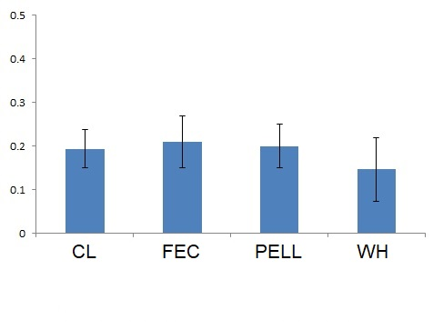

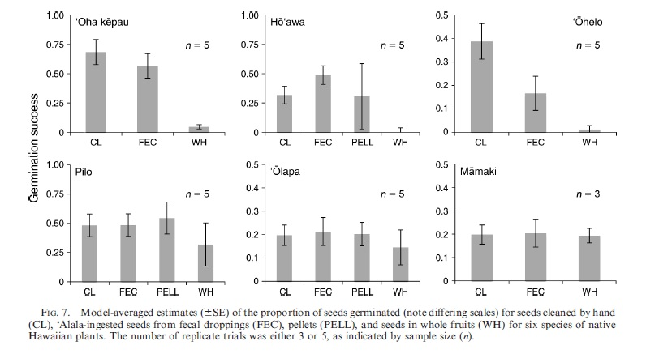

**Resultados generales del artículo** Los Alalas comieron y llevaron las 14 frutas en este estudio, incluidos las de loulu y halapepe, dos plantas en peligro de extinción de las que se desconocen los dispersores actualmente. Los resultados indican que h¯o‘awa se basa totalmente en la ingestión o manipulación de Alal¯a para la germinación, y que la germinación de ‘¯ohelo y‘ oha k¯epau se incrementó por la ingestión de los Alalas, en comparación con las semillas de frutos enteros. Estos hallazgos sugieren que Alala fue una vez un importante dispersor de semillas en bosques mésicos y secos en la isla grande de Hawái.

##### **4.** ¿Qué cosas están en los materiales suplementarios que no están mencionadas en los métodos?

- Código
- Figuras a color

¿y son importantes para entender el análisis?

No

##### **5.** ¿Qué cosas están en los métodos que no encontraron en el código?

- El orden de cada uno de los experimentos
- Los detalles:Características de los recintos de los animales, la forma de darles cada fruto,la colecta de las plantas con frutos, la explicación de la estadística utilizada.

##### **6.** Características del artículo y/o materiales suplementarios que dificultaron la reproducción

El Artículo es del 2012 - Los paquetes han cambiado (Muy poco) - No incluye el código para los gráficos - Hay links para scrips que no sirven (Pero está disponible el código en word)

##### **7.** Características del artículo y/o materiales suplementarios que facilitaron la reproducción

- El código está muy bien explicado
- Código en M Word, se puede copiar y pegar en RStudio
- Los métodos son muy claros

##### **8.** ¿Considera que el análisis de datos es reproducible?

**¡Sí!** Si bien tuve algunos inconvenientes por los cambios en los paquetes estos no me impidieron obtener resultados muy iguales a los de las investigadoras originales. Aún así creo que el código para hacer las figuras debería de incluirse así como incluyeron el código para los análisis. No entendí por qué utilizaban excel para exportar los resultados de cada análisis y sospecho que puede ser que estuvieran usando otros programas para hacer cuadros y gráficos en lugar de R (*yo usé excel entonces*). Finalmente, aunque el artículo fue públicado hace 8 años era muy claro y accesible, más que muchos artículos más nuevos.

**OJO** Mi manera de buscar un artículo para reproducir NO fue al azar. Escogí primero una investigadora cuyos artículos yo sabía que iban a ser abiertos y con código abierto en su mayoría y a quien pudiera contactar fácilmente en caso necesario (*no fue necesario*). Luego escogí los artículos que me interesaran pero que no incluyeran procesos estadísticos demasiado complejos de reproducir (*Para mi*). Por último, de los restantes artículos escogí el que era en cautiverio (*tipo experimento, con tratamientos*) y que tenía los métodos bien claros.

**Acá pueden acceder al** [Repositorio en github](https://github.com/MolinaIngrid/Reproduccion_Culliney_2012) donde están todos los resultados para cada una de las especies de plantas y todo el código modificado y archivos de excel, imágenes etc. que hice para este proyecto de reproducción.